# Final Project- Price of Used Cars

Mulberry Fu, Xinye Xu, Yuxin Zhang

Dec 4

**1. Abstract**

In this project, we established nonlinear multiple regression model to study the influencing factors of the car prices, among which the variable of interest is the body-size. The results show that the price of used cars heavily depends on the the body size where convertible cars are the most expensive, followed by full-size cars, and median-size cars have the lowest prices. Body size affects price the most, and condition has the second greatest causal effect on price. Asian-brand cars are slightly pricier than non Asian-brand cars. Odometer and year-used have negative effects on price.

**2. Introduction**

**2.1 Dataset Overview**

The dataset comes from Kaggle: https://www.kaggle.com/tunguz/used-car-auction-prices.

This dataset provides us with over 400,000 cars’ detailed information before 2015. It covers 16 columns such as year, make, prices, body-size, odometer, condition of vehicles and transmission and so on. It gives us a comprehensive understanding of factors on trading market. So the dataset is pretty relevant to our topic, and suitable for carrying out research as well.

**2.2 Fundamental Question**

How does body size affect prices of used-cars?

**2.3 Hypothesis**

The larger the body size, the higher the price.

**2.4 Limitation of Data**

Yet there are some limitations of the data.

First, the classification of body-size is too general. Body-size is only divided into 3 categories since we try to make it simple and much easier to use. Therefore, the result might also be too general in terms of the relationship between every body size and the prices of used cars.

Second, vehicles were not sampled proportionally from each state.

Third, there are many other factors that may affect the prices of used cars that are not included in the dataset. For example, miles per gallon.

Finally, prescription and market changes. The data mainly focus on used cars before 2015, so that what we conclude from that dataset is only a general explanation or research of used cars’ price in that period of time. In recent years, price rise caused by chip shortage and the spread of electric cars undoubtedly have big influences on the price of used cars. But the missing data of recent years really put limitations on us.

**3. Data**

**3.1 Selection of Variables**

In the choice of the variables, below are all variables that we choose in this project.

Y in Baseline Regression: price – price of the used car unit:USD Y in Alternative Regression: Log(price) – Log of price of the used car unit:USD X : Variable of interest: body_size – the body size of the used cars, without unit

– body_size_convertible: 1 if size of the used cars is convertible

– body_size_median_size: 1 if the used cars is median sized

– body_size_full_size: 1 if the used cars is full sized

AsianBrand: 1 if the used car is Asian brand else 0, without unit

new_odo: Mileage of the used car divided by 5000, unit :mile

new_odo^2: Squared new-odo

year_used: The number of years that the used car have been used, without unit

year_used^2: Squared the number of years that the used car have been used

year_used^3: Cubic the number of years that the used car have been used

condition: The rate of used car’s condition(from 1 to 5), 1 being salvage, 5 being like new, without unit

condition*new_odo: The interaction of condition and new_odo

Below are descriptive statistics for some important variables that we use

All of them have relatively high standard deviation, which means the data is widely spread

**3.2 Statistics Description**

```
Descriptive statistics for rd, sales, profits
===========================================
Statistic    N      Mean    Median St. Dev.
-------------------------------------------
price     460,309 13,263.43 11,800 9,721.14
year_used 460,309   5.85      4      3.92
new_odo   460,309   13.25   10.06   10.33
condition 460,309   3.44     3.6     0.93
-------------------------------------------
```

**4. Regression Tools**

```
Car Price Beseline Regression
=================================================================================
                                          Dependent variable:
                      -----------------------------------------------------------
                                                 price
                          (1)         (2)         (3)         (4)         (5)
---------------------------------------------------------------------------------
body_size_convertible 6,015.6130  5,785.9720  5,599.6960  6,997.3180  6,562.7340
                      (159.6886)  (159.8021)  (136.9455)  (133.9694)  (130.5645)

body_size_full_size   3,642.3460  3,574.8470  4,724.4640  4,565.5410  3,959.8800
                       (30.3505)   (30.5903)   (24.5432)   (23.3652)   (23.3117)

AsianBrand                         -708.8922   -898.7261   -860.9579   -764.1112
                                   (26.5330)   (21.0983)   (20.4564)   (19.7280)

new_odo                                        -560.8168   -327.9028   -266.3424
                                               (2.8867)    (4.0157)    (3.5556)

year_used                                                  -778.9747   -607.5764
                                                           (8.3043)    (7.0246)

condition                                                             2,330.6800
                                                                       (13.4988)

Constant              11,824.8500 12,108.3600 19,197.9000 20,680.5500 11,042.9400
                       (16.1598)   (21.8329)   (41.6833)   (27.4797)   (55.4148)

---------------------------------------------------------------------------------
Observations            460,309     460,309     460,309     460,309     460,309
R2                      0.0370      0.0382      0.3899      0.4276      0.4614
Adjusted R2             0.0370      0.0382      0.3899      0.4276      0.4614
Residual Std. Error   9,539.6950  9,533.7490  7,592.8110  7,354.8500  7,134.6030
F Statistic           8,839.4130  6,092.0760  73,557.1200 68,768.8000 65,709.9700
=================================================================================
Note:                                                                          NA
```

We figure that AsianBrand, new_odo, year_used, and condition can have a great effect on price, so we run regression one by one to see how they affect the price and how much they affect the effect of body size on price.

**Table 1:**

- Model 1:

A convertible car is 6016 dollars more expensive than a mid-size car. A full-size car is 3642 dollars more expensive than a mid-size car. A mid-size car has an average price of 11825 dollars.

- Model 2:

Holding everything else constant, if a car is an Asian brand, it will be 709 dollars cheaper than one isn’t. With the variable AsianBrand added into the regression, adjusted R-square increases, both the coefficient of body_size_convertible and body_size_full_size decreases with fluctuation less than 5%, they suffer from upward bias in Model 1.

- Model 3:

- Model 4:

Holding everything else constant, if a car has one more year of use, it will have a decrease of 779 dollars in price. With the variable year_used added into the regression, adjusted R-square increases by 4%, the coefficient of body_size_convertible increases by 25% and that of body_size_full_size decreases by 3% compared with model 3. The coefficient of AsianBrand increases by 4% and the coefficient of new_odo increases by 42%. Constant increases by 8%. Overall, year_used makes a big difference with a relative substantial impact on the fitness of the regression.

- Model 5:

Holding everything else constant, if a car has a higher condition index of one, it will be 2331 dollars more expensive. With the variable condition added into the regression, adjusted R-square increases by 3%, the coefficient of body_size_convertible decreases by 6% and that of body_size_full_size decreases by 13% compared with model 4. The coefficient of AsianBrand increases by 11% and the coefficient of new_odo increases by 19%. Constant decreases by 47%. Overall, condition is also statistically significant and affects the constant a lot. Up to this point, model 5 has been the greatest fit.

- Summary:

Even though very term in table 1 is statistically significant, the coefficients of body_size_convertible and body_size_full_size vary a lot when a new variable is introduced, meaning that the model is suffering from omitted variable bias. We make a plot of each control variable versus price to see whether it has a linear or nonlinear relationship with price. It turns out that odometer and year_used have nonlinear relationships with price. In order to mitigate bias, we decide to try to use log of price as dependent variable.

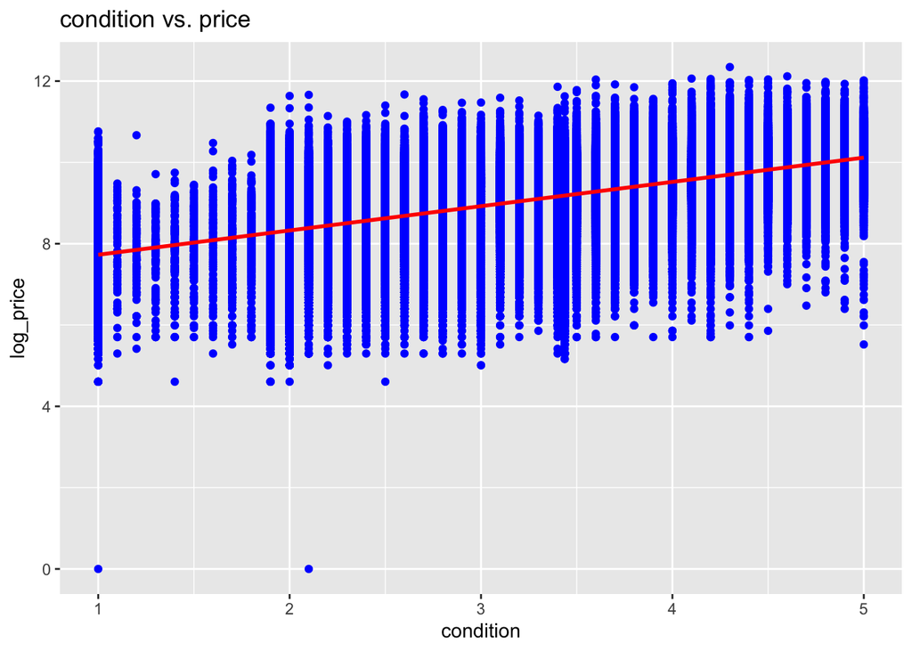

```
Car Price Alternative Regression
===================================================================================================
                                                   Dependent variable:
                      -----------------------------------------------------------------------------
                                                 log(price)                               price
                          (1)          (2)          (3)          (4)          (5)          (6)
---------------------------------------------------------------------------------------------------
body_size_convertible    0.5067       0.4847       0.4945       0.4572       0.4671
                        (0.0064)     (0.0063)     (0.0062)     (0.0058)     (0.0060)

body_size_full_size      0.3761       0.3673       0.3717       0.3157       0.3109
                        (0.0015)     (0.0015)     (0.0015)     (0.0015)     (0.0015)

AsianBrand               0.0389       0.0407       0.0325       0.0420       0.0463
                        (0.0015)     (0.0014)     (0.0014)     (0.0014)     (0.0014)

new_odo                 -0.0323      -0.0409      -0.0411      -0.0338      -0.0306      -27.9238
                        (0.0003)     (0.0003)     (0.0003)     (0.0003)     (0.0009)     (5.9066)

year_used               -0.1254      -0.0182       0.1199       0.1479       0.1163
                        (0.0005)     (0.0012)     (0.0019)     (0.0018)     (0.0019)

I(year_used2)                        -0.0058      -0.0229      -0.0241      -0.0220
                                     (0.0001)     (0.0002)     (0.0002)     (0.0002)

I(year_used3)                                      0.0006       0.0006       0.0006
                                                 (0.00001)    (0.00001)    (0.00001)

condition:new_odo                                                                       -126.0090
                                                                                         (1.7641)

condition                                                       0.2085       0.1912     4,631.7690
                                                               (0.0010)     (0.0029)    (30.9004)

I(new_odo2)              0.0001       0.0002       0.0002       0.0001
                       (0.00001)    (0.000003)   (0.000004)   (0.000003)

new_odo:condition                                                            0.0018
                                                                            (0.0002)

Constant                10.1635       9.9178       9.6473       8.7429       8.8261     2,815.4680
                        (0.0020)     (0.0027)     (0.0038)     (0.0055)     (0.0128)    (114.7172)

---------------------------------------------------------------------------------------------------
Observations            460,309      460,309      460,309      460,309      460,309      460,309
R2                       0.6997       0.7129       0.7187       0.7492       0.7472       0.4120
Adjusted R2              0.6997       0.7129       0.7187       0.7492       0.7472       0.4120
Residual Std. Error      0.4983       0.4872       0.4823       0.4554       0.4572     7,454.2670
F Statistic           178,773.0000 163,302.2000 147,039.2000 152,793.6000 151,149.0000 107,511.8000
===================================================================================================
Note:                                                                                            NA
```

**Table2:**

- Model 1:

Holding everything else constant,if a car is a convertible, it will have a 50.67% higher price than a mid-size car, the 95% confidence interval of body_size_convertible is [0.4942, 0.5192]. If a car is full-size, it will have a 37.61% higher price than a mid-size car, the 95% confidence interval of body_size_full_size is [0.37316, 0.37904]. If a car is an Asian brand, it will have a 3.89% higher price than one that isn’t. In this regression, Asian cars tend to be pricier, while the Asian cars are cheaper than non-Asian cars in table 1. It’s probably because that in Table 1, some of the Asian cars have very low prices and thus drive the coefficient of AsianBrand lower than it should. While in table 2, the log of price is mitigating the effect of outliers thus the coefficient of AsianBrand isn’t affected by that much. If a car has an increase of 5000 miles in odometer, for example, the estimated effect of increasing new_odo from 5 to 6 (odometer from 25000 to 30000) on price is ∆ price= -0.0323(6-5)+0.0001（6^2 - 5^2）= -0.0312, the price will decrease by 3%. If a car has one more year uses, the price will decrease by 12.54%. The average price of a non-Asian brand mid-size car is e^10.1635=25939 dollars.

- Model 2:

- Model 3:

∆ price= -0.0411(6-5)+0.0002（6^2 - 5^2）= -0.0389, the price will decrease by 4%.

We run a F-test on year_used^2 =0 and year_used^3 =0, the F-stat is 11773, so we reject the null with 1% confidence, conclude that at least one of year_used^2 and year_used^3 is significant. The coefficient of both year_used^2 and year_used^3 are statistically significant by t-test, so we keep them both in our regression.

With year_used^3 added in the regression, the coefficient of year_used changes sign and becomes positive, but the three terms combined together still gives a negative (-0.0774) effect on price.

- Model 4:

Holding everything else constant, a convertible car has a 45.72% higher price than a mid-size car. A full-size car has a 31.57% higher price than a mid-size car. Both coefficients of body_size_convertible and body_size_full_size decrease to outside of their regrading confidence interval, they suffer from upward bias in Model 3.

Holding everything else constant, if a car is an Asian brand, it will have a 4.2% higher price than one isn’t. A mid-size non-Asian brand car has an average price of e^8.7429=6266 dollars.

Holding everything else constant, if a car has an increase of 5000 miles in odometer, for example, the estimated effect of increasing new_odo from 5 to 6 (odometer from 25000 to 30000) on price is ∆ price= -0.0338(6-5)+0.0001（6^2 - 5^2）= -0.0327

Holding everything else constant, if a car has an increase of one year in year_used, for example, the estimated effect of increasing year_used from 5 to 6 on price is ∆ price= 0.1479(6-5)-0.0241（6^2 - 5^2）+ 0.0006(6^3 - 5^3)= -0.0626

If a car has a better condition index of one, it will be 20.85% more expensive.

- Model 5:

Holding everything else constant, a convertible car has a 46.71% higher price than a mid-size car. A full-size car has a 31.09% higher price than a mid-size car.

Holding everything else constant, if a car has an increase of 5000 miles in odometer, the price will decrease by 3%.

Holding everything else constant, if a car has an increase of one year in year_used, for example, the estimated effect of increasing year_used from 5 to 6 on price is ∆ price= 0.1163(6-5)-0.0220（6^2 - 5^2）+ 0.0006(6^3 - 5^3)= -0.0711

If a car has a better condition index of one, it will be 19.12% more expensive.

The estimated effect of condition on price increase with new_odo: ΔLog(price)/Δcondition = 0.1912 + 0.0018*new_odo The estimated effect of odometer on price increase with condition: ΔLog(price)/Δnew_odo = -0.0306 + 0.0018*condition

```
Linear hypothesis test

Hypothesis:
I(year_used^2) = 0
I(year_used^3) = 0

Model 1: restricted model
Model 2: log(price) ~ body_size_convertible + body_size_full_size + AsianBrand +
    new_odo + I(new_odo^2) + year_used + I(year_used^2) + I(year_used^3)

Note: Coefficient covariance matrix supplied.

  Res.Df Df     F    Pr(>F)
1 460302
2 460300  2 11773 < 2.2e-16 ***
---
Signif. codes:  0 '***' 0.001 '**' 0.01 '*' 0.05 '.' 0.1 ' ' 1
```

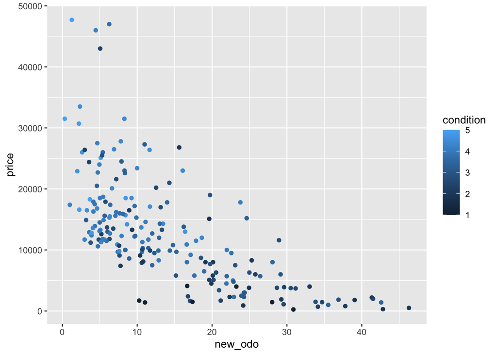

[output not shown]

**5. Interpretation**

Even though model 4 has the highest adjusted R-square, we choose model 5 as our final model because we want to include the interaction term which is statistically significant and reveals the relationship between condition and odometer.

**$log(price)=0.4671*bodysizeconvertible + 0.3109*bodysizefullsize + 0.0463*Asianbrand$**

**$-0.0306*newodo + 0.1163*yearused - 0.022*yearused^2 + 0.0006*yearused^3$**

**$+0.1912*condition + 0.0018*condition*newodo + 8.8261$**

More detailed interpretation on our model:

- body_size:

The slope of body-size-convertible is 0.4671, which means holding other variables constant, the average selling price of body_size_convertible car is 46.71% more than the body_size_mid_size cars. By calculating the t-stat of body-size-convertible slope: 0.4671/0.0060 > 2.33, we can reject the null hypothesis in 1% significance level.

The slope of body-size-convertible is 0.3109, which means holding other variables constant, the average selling price of body_size_full_size car is 31.09% more than the body_size_mid_size cars. By calculating the t-stat of body-size-full_size slope: 0.3109/0.0015 > 2.33, we can reject the null hypothesis in 1% significance level.

- AsianBrand:

- new_odo:

The slope of the new_odo is -0.0306, which means holding other variables constant, when the new_odo increases by 1 unit(odometer increases by 5000), the selling price will decrease by 3.06%. By calculating the t-stat of new_odo slope: -0.0306/0.0009 <-2.33, it is statically significant in 1% significance level.

- year_used:

- condition:

We can see that in regression, the slope of the condition is 0.1912, which means holding other variables constant, when the condition increases by 1 unit, the selling price will increase by 19.12%. By calculating the t-stat of condition slope: 0.1912/0.0029 >2.33, it is statically significant in 1% significance level.

- Interaction:

In this regression, we can see that the effect of condition on selling price varies with the odometer of the car and at the same time, the effect of the odometer on selling price varies with the condition of the car.

The estimated effect of condition on price increases with odometer:

ΔLog(price)/Δcondition = 0.1912 + 0.0018*new_odo

The estimated effect of odometer on price increases with condition:

ΔLog(price)/Δnew_odo = -0.0306 + 0.0018* condition

The interaction term is statistically significant: t = 0.0018/0.0002 > 2.33，we can reject the null hypothesis that the interaction term is zero.

- R^2 and SER:

The R square is 0.7472, which means our regression can explain 74.72% of variation in car price.

The SER is 0.4572, which shows the spread of the residuals around the fitted curve.

**6. Conclusion:**

The average price of median_size car, the average price of the convertible car, and the average price of full_size car are different. However, the price doesn’t increase with the size of a car. Holding other variables constant, the average selling price of a convertible car is 46.71% more than a median size car, and the average selling price of a full size car is 31.09% more than a median size car. The results contradict our assumption that bigger cars cost more because although full size cars do cost more than median size cars, it is obvious that the convertible cars (with the smallest size), cost the most on average.

We use multiple regression to fit the sample because it mitigates the problem of omitted variable bias. What’s more, our model handles the non-linear regression well. From the plot of each control price versus price, it is clear that new_odo and year_used has nonlinear relationships with price, so we try to use different kinds of alternative specifications such as polynomials and interaction into the regression (year_used cubic, new_odo square, and condition*new_odo) to make the regression fit the population better.

**7. Threats**

**7.1 External validity in our regression**

During the COVID-19, the price of used cars has changed greatly, and the past data cannot represent the current used car market. Additionally, electric vehicles also occupy a large market share while there is very few data about electric cars included in our dataset, thus, our model does not reflect the price fluctuation of the current used car market In this way, our regression can only fit past samples, but cannot predict all used car data in the future.

**7.2 Internal validity in our regression**

1)The author of the dataset didn’t specify how he collect the data, but it is highly possible that the vehicles were not proportionally picked from each state. Each state has different levels of wealth and preferences in choosing the types of vehicles, for example, California residents have higher income and prefer median sized cars while Ohio residents have lower income and prefer full size cars. Therefore, There might be sample selection bias.

2)Miles per gallon(MPG) is not included in this dataset. The distance a car can drive with one gallon of gasoline may affect the price of a car, and it may also affects the mileage of a used car, because if the owner owns a car that is not fuel-efficient, he/she may take public transportation more than drive a car. In addition, MPG also has a relationship with the dummy variable AsianBrand and body_size, in common sense, Asian brand cars and median sized cars are considered more fuel-efficient.